# Reproducible Research: Peer Assessment 1

###Installing the required external packages and loading them for use

```r
install.packages("zoo")
```

```
## Error: trying to use CRAN without setting a mirror
```

```r
library("zoo")
```

## Loading and preprocessing the data

###Read data from the csv file from the working directory

```r
Activity <- read.csv("~/Rwork/activity.csv")
```

###Convert the columns into corresponding suitable formats, i.e., Date for date and numeric for the others

```r
Activity$steps <- sapply(Activity$steps, as.numeric)
Activity$interval <- sapply(Activity$interval, as.numeric)
Activity$date <- as.Date(Activity$date, "%Y-%m-%d")
```

## What is mean total number of steps taken per day?

###Computing the total number of steps in a day and plotting the histogram

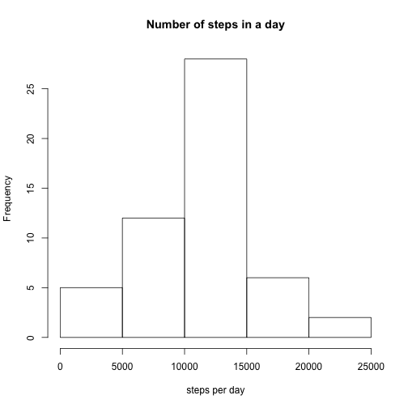

```r
stepsDay <- tapply(Activity$steps, Activity$date, sum, simplify = TRUE)
hist(stepsDay, xlab = "steps per day", main = "Number of steps in a day")
```

###Computing the mean and the median of total number of steps per day

```r
median(stepsDay, na.rm = TRUE)
```

```
## [1] 10765
```

```r
mean(stepsDay, na.rm = TRUE)
```

```
## [1] 10766
```

## What is the average daily activity pattern?

###Computing the average number of steps at a given time interval across all days and plotting them as a line graph

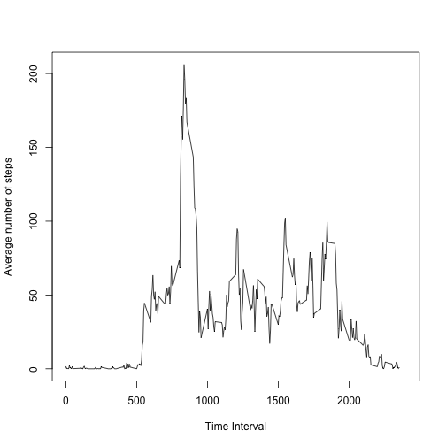

```r
avgStepsPerTime <- tapply(Activity$steps, Activity$interval, mean, na.rm = T)
plot(avgStepsPerTime ~ Activity$interval[1:288], type = "l", xlab = "Time Interval",
    ylab = "Average number of steps", xlim = c(0, 2400))
```

###Identify the time interval that contains the maximum number of steps on an average

```r
intervalMax <- which(avgStepsPerTime == max(avgStepsPerTime))
names(intervalMax)
```

```
## [1] "835"
```

## Imputing missing values

###Total number of missing values in the dataset

```r
sum(is.na(Activity$steps))
```

```
## [1] 2304
```

###Replacing the NAs with the mean value of the time interval where NAs were originally found (using the 'zoo' package)

```r
Activity$steps <- na.aggregate(Activity$steps, by = Activity$interval, fun = mean)
```

###Calculating the new mean number of steps in a day and plotting the required histogram

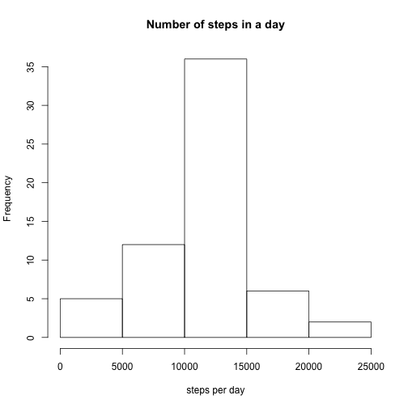

```r
newStepsDay <- tapply(Activity$steps, Activity$date, sum, simplify = TRUE)
hist(newStepsDay, xlab = "steps per day", main = "Number of steps in a day")
```

###Computing the new mean and median total number of steps taken per day

```r
median(newStepsDay)
```

```
## [1] 10766
```

```r
mean(newStepsDay)
```

```
## [1] 10766
```

The total number of steps have increased in those days that had missing values originally. Logically, this is sound since we can see that the number of steps (so imputed) cannot be negative and therefore should lead to an increase in the daily number of steps value.

## Are there differences in activity patterns between weekdays and weekends?

###Creating a factor variable in the dataset to represent whether it is a weekday or a weekend

```r
Activity$day <- weekdays(Activity$date)
Activity$weektype <- factor(ifelse(grepl("Sun|Sat", Activity$day) == TRUE, "weekend",
    "weekday"))
```

###Create a planel plot to represent average number of steps per time interval for weekday and weekend using base plotting system

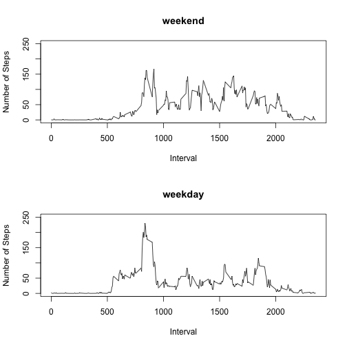

```r
par(mfrow = c(2, 1))
summary <- by(Activity$steps, Activity[, c(3, 5)], mean, simplify = TRUE)
plot(summary[, 2] ~ Activity$interval[1:288], type = "l", main = "weekend",
    xlab = "Interval", ylab = "Number of Steps", ylim = c(0, 250))
plot(summary[, 1] ~ Activity$interval[1:288], type = "l", main = "weekday",
    xlab = "Interval", ylab = "Number of Steps", ylim = c(0, 250))
```

There is clearly a difference in the activity on an weekday and that on a weekend as illustrated by the above graphs.